# Why we can filter — quantitative rationale

Anton

2026-05-30

# Purpose of this document

This document argues — both structurally and biologically — that restricting the dataset to one cohort (`Project.ID == "PRJNA422434"`, the Chinese case-control study) yields a more interpretable and biologically meaningful comparison than analysing the full 432-sample dataset. Every claim is supported by the relevant test run on the unfiltered data.

The argument has two layers:

1. **Structural** — the design of the other two projects makes them unusable for case-control inference.
2. **Biological** — even if the other projects had controls, mixing populations would degrade rather than improve the biological signal we want to detect.

# 1. Libraries

```r
library(phyloseq)
library(vegan)
library(ggplot2)
library(dplyr)
library(tibble)
library(tidyr)
library(knitr)
```

> *Reference: same library stack used in W20-01, W20-02 and W20-03 (phyloseq, tidyverse, tibble) and W20-03 (vegan).*

# 2. Load the unfiltered dataset

```r
load("project/data/D003924_Diabetes_Mellitus,_T/genus/phyloseq.RData")
ps_raw <- pylsq
rm(pylsq)

ps_raw
```

```
## phyloseq-class experiment-level object
## otu_table()   OTU Table:         [ 58 taxa and 432 samples ]
## sample_data() Sample Data:       [ 432 samples by 12 sample variables ]
## tax_table()   Taxonomy Table:    [ 58 taxa by 7 taxonomic ranks ]
## phy_tree()    Phylogenetic Tree: [ 58 tips and 27 internal nodes ]
```

> *Reference: phyloseq object construction/inspection pattern from W20-01 §“Create the phyloseq object” + §“Inspect the components”.*

# 3. Disease distribution

```r
table(sample_data(ps_raw)$Disease.MESH.ID, useNA = "ifany")
```

```
##
## D003924 D006262
##     260     172
```

> *Reference: metadata inspection from W20-01 §“Inspect the components” (uses `sample_data(ps)` and tabulates).*

# 4. ProjectIDs

```r
table(sample_data(ps_raw)$Project.ID, useNA = "ifany")
```

```
##
##   PRJEB1786 PRJNA299502 PRJNA422434
##          54          19         359
```

> *Reference: metadata inspection from W20-01 §“Inspect the components”; cohort/country exploration explicitly endorsed by Urvish in Slack (“plot your data with multiple countries first…”).*

Are they from three different studies? This would introduce more than just geographical noice.

# 5. ProjectID x MeshID

```r
table(sample_data(ps_raw)$Project.ID,
      sample_data(ps_raw)$Disease.MESH.ID)
```

```
##
##               D003924 D006262
##   PRJEB1786        54       0
##   PRJNA299502      19       0
##   PRJNA422434     187     172
```

> *Reference: cross-tabulation of two metadata variables — extension of W20-01 §“Inspect the components” pattern; the design rationale (checking case/control balance per study) is the Slack-endorsed exploratory step.*

Two of three studies contain no healthy controls at all.

# 6. Country structure

```r
table(sample_data(ps_raw)$Country,
      sample_data(ps_raw)$Project.ID)
```

```
##
##                            PRJEB1786 PRJNA299502 PRJNA422434
##   China                            0           0         359
##   Denmark                          2           0           0
##   Estonia                          1           0           0
##   Finland                          1           0           0
##   Germany                          2           0           0
##   Hungary                          1           0           0
##   Sweden                          46           0           0
##   United States of America         0          19           0
##   Yugoslavia                       1           0           0
```

```r
table(sample_data(ps_raw)$Country,
      sample_data(ps_raw)$Disease.MESH.ID)
```

```
##
##                            D003924 D006262
##   China                        187     172
##   Denmark                        2       0
##   Estonia                        1       0
##   Finland                        1       0
##   Germany                        2       0
##   Hungary                        1       0
##   Sweden                        46       0
##   United States of America      19       0
##   Yugoslavia                     1       0
```

> *Reference: metadata cross-tabulations; cohort/country exploration explicitly endorsed by Urvish in Slack.*

PRJNA422434 = China

# 7. Is there a significant difference between the cohorts?

This section runs the tests that demonstrate how strongly cohort drives community variation.

## 7.1 Compute Bray-Curtis distance on full data

```r
ps_rel_full    <- transform_sample_counts(ps_raw, function(x) x / sum(x))
bray_full      <- distance(ps_rel_full, method = "bray")
sample_df_full <- sample_data(ps_rel_full) |> data.frame()
```

> *Reference: W20-03 §“Preparing transformed phyloseq objects” + §“Calculating beta-diversity distances”.*

## 7.2 PCoA — coloured by Project

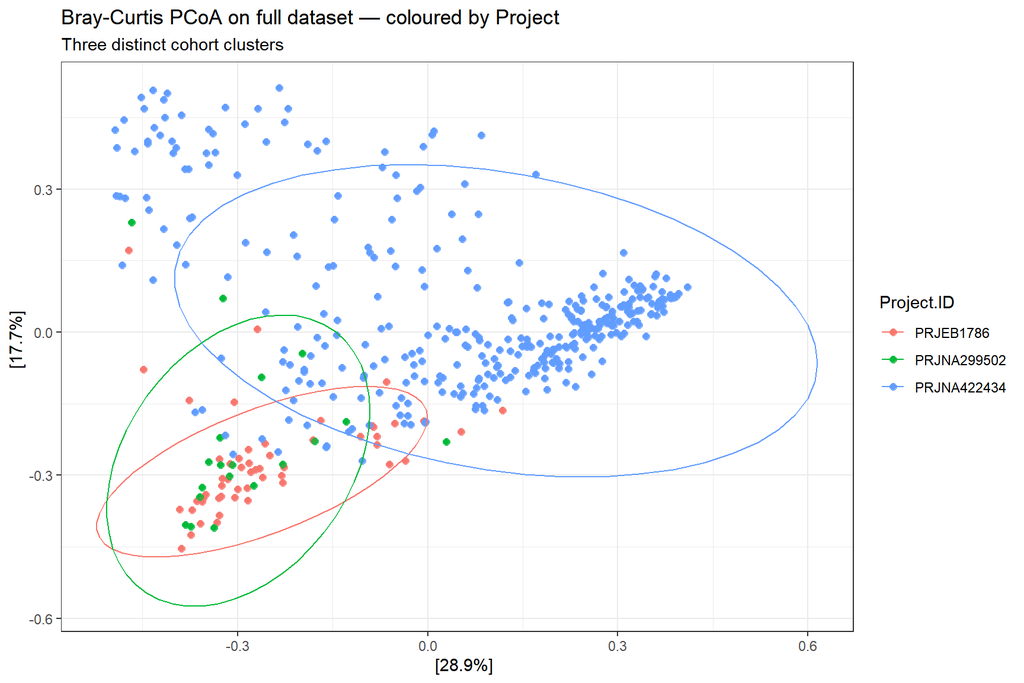

```r
ord_full <- ordinate(ps_rel_full, method = "PCoA", distance = bray_full)

plot_ordination(ps_rel_full, ord_full, color = "Project.ID") +
  geom_point(size = 2, alpha = 0.7) +
  stat_ellipse(level = 0.95) +
  theme_bw() +
  labs(title = "Bray-Curtis PCoA on full dataset — coloured by Project",
       subtitle = "Three distinct cohort clusters")
```

> *Reference: W20-03 §“PCoA based on Bray-Curtis distance” — uses `ordinate(method = "PCoA")` and `plot_ordination()` coloured by a metadata variable.*

## 7.3 PCoA — coloured by Disease (same samples, same positions)

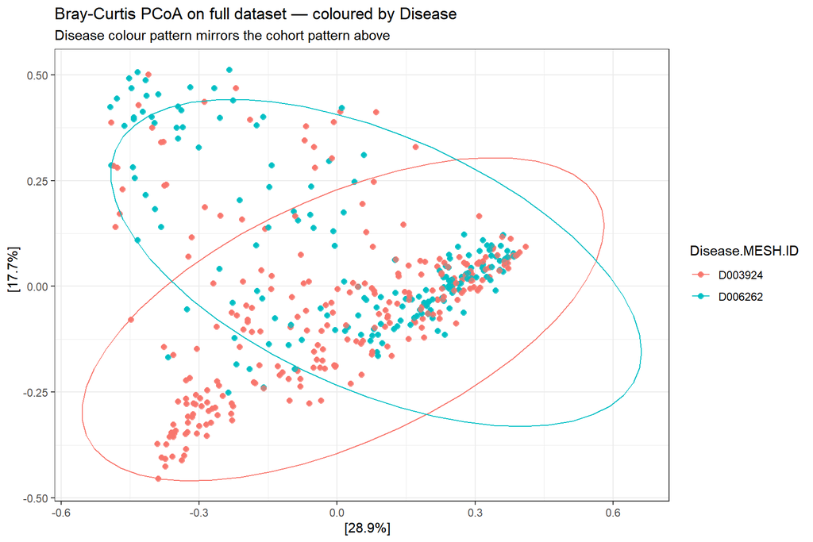

```r
plot_ordination(ps_rel_full, ord_full, color = "Disease.MESH.ID") +
  geom_point(size = 2, alpha = 0.7) +
  stat_ellipse(level = 0.95) +
  theme_bw() +
  labs(title = "Bray-Curtis PCoA on full dataset — coloured by Disease",
       subtitle = "Disease colour pattern mirrors the cohort pattern above")
```

> *Reference: same `plot_ordination()` call as the previous chunk, just recolored — W20-03 §“PCoA based on Bray-Curtis distance”.*

The two plots show the same samples in the same positions; only the colour differs. If the disease colouring traces the same shape as the project colouring, what looks like a “T2D vs Healthy” pattern is being driven by cohort membership.

## 7.4 PERMANOVA on Project alone

How much variance does cohort itself explain?

```r
adonis2(bray_full ~ Project.ID,
        data = sample_df_full,
        permutations = 999)
```

```
## Permutation test for adonis under reduced model
## Permutation: free
## Number of permutations: 999
##
## adonis2(formula = bray_full ~ Project.ID, data = sample_df_full, permutations = 999)
##           Df SumOfSqs      R2      F Pr(>F)
## Model      2   12.689 0.12887 31.732  0.001 ***
## Residual 429   85.777 0.87113
## Total    431   98.467 1.00000
## ---
## Signif. codes:  0 '***' 0.001 '**' 0.01 '*' 0.05 '.' 0.1 ' ' 1
```

> *Reference: W20-03 §“Testing Bray-Curtis distances across body sites” — uses the identical `adonis2(distance ~ group, data = sample_df, permutations = 999)` pattern. Conceptually grounded in Alberdi’s multivariate-statistics lecture (PERMANOVA).* Permanova on the full dataset shows that ProjectID explains ~13% of the variance (R^2 = 0.12887) with a large f statistic (F = 31.73) and a significant P-value (0.001).

## 7.5 PERMANOVA on Country alone

Country is partly a relabelling of Project, but verifying same pattern:

```r
adonis2(bray_full ~ Country,
        data = sample_df_full,
        permutations = 999)
```

```
## Permutation test for adonis under reduced model
## Permutation: free
## Number of permutations: 999
##
## adonis2(formula = bray_full ~ Country, data = sample_df_full, permutations = 999)
##           Df SumOfSqs      R2     F Pr(>F)
## Model      8   14.006 0.14224 8.768  0.001 ***
## Residual 423   84.461 0.85776
## Total    431   98.467 1.00000
## ---
## Signif. codes:  0 '***' 0.001 '**' 0.01 '*' 0.05 '.' 0.1 ' ' 1
```

For comparison:

```r
adonis2(bray_full ~ Disease.MESH.ID,
        data = sample_df_full,
        permutations = 999)
```

```
## Permutation test for adonis under reduced model
## Permutation: free
## Number of permutations: 999
##
## adonis2(formula = bray_full ~ Disease.MESH.ID, data = sample_df_full, permutations = 999)
##           Df SumOfSqs      R2      F Pr(>F)
## Model      1    2.918 0.02964 13.134  0.001 ***
## Residual 430   95.548 0.97036
## Total    431   98.467 1.00000
## ---
## Signif. codes:  0 '***' 0.001 '**' 0.01 '*' 0.05 '.' 0.1 ' ' 1
```

> *Reference: same `adonis2()` pattern — W20-03 §“Testing Bray-Curtis distances across body sites”.* For comparison, Disease alone on the unfiltered dataset explained 2.964% of variance (F = 13.13, p = 0.001)

## 7.7 Adjusted PERMANOVA: Project and Disease together

The decisive test. With both terms in the model and `by = "margin"`, each is tested adjusted for the other:

```r
adonis2(bray_full ~ Project.ID + Disease.MESH.ID,
        data = sample_df_full,
        by = "margin",
        permutations = 999)
```

```
## Permutation test for adonis under reduced model
## Marginal effects of terms
## Permutation: free
## Number of permutations: 999
##
## adonis2(formula = bray_full ~ Project.ID + Disease.MESH.ID, data = sample_df_full, permutations = 999, by = "margin")
##                  Df SumOfSqs      R2       F Pr(>F)
## Project.ID        2   11.129 0.11302 28.2119  0.001 ***
## Disease.MESH.ID   1    1.358 0.01379  6.8853  0.001 ***
## Residual        428   84.419 0.85734
## Total           431   98.467 1.00000
## ---
## Signif. codes:  0 '***' 0.001 '**' 0.01 '*' 0.05 '.' 0.1 ' ' 1
```

## 7.8 betadisper — Project

A significant PERMANOVA could in principle reflect different dispersions rather than different centroids. We check that the project effect is a centroid shift:

```r
disp_project <- betadisper(bray_full, sample_df_full$Project.ID)
anova(disp_project)
```

```
## Analysis of Variance Table
##
## Response: Distances
##            Df Sum Sq  Mean Sq F value  Pr(>F)
## Groups      2 0.1665 0.083261  3.7639 0.02396 *
## Residuals 429 9.4898 0.022121
## ---
## Signif. codes:  0 '***' 0.001 '**' 0.01 '*' 0.05 '.' 0.1 ' ' 1
```

> *Reference: W20-03 §“Checking homogeneity of dispersion” — uses `betadisper(dist, group)` followed by `anova()`.* betadisper on Project.ID showed significantly heterogeneous dispersions (F = 3.76, p = 0.024), indicating that part of the project effect reflects unequal within-cohort variability — plausibly attributable to PRJEB1786 spanning seven European countries internally. However, the dispersion F is approximately 8× smaller than the PERMANOVA F (31.73), meaning centroid differences remain the dominant component of the project effect. Both interpretations — centroid shift and dispersion difference — represent cohort confounding that the filtering decision addresses.

# 8. Cohort effects on alpha diversity

The cohort effect is not only multivariate. Within-sample diversity also differs by project.

## 8.1 Compute Shannon on full data

```r
shannon_full <- estimate_richness(ps_raw, measures = "Shannon") |>
  rownames_to_column("sample_id")

meta_full <- sample_data(ps_raw) |>
  data.frame() |>
  rownames_to_column("sample_id")

alpha_full <- inner_join(shannon_full, meta_full, by = "sample_id")
head(alpha_full)
```

```
##   sample_id  Shannon    Run.ID Project.ID Experiment.type Nr..reads.sequenced
## 1 ERR260139 1.737425 ERR260139  PRJEB1786    Metagenomics            10082557
## 2 ERR260140 1.824070 ERR260140  PRJEB1786    Metagenomics             9583450
## 3 ERR260144 1.891846 ERR260144  PRJEB1786    Metagenomics            12296547
## 4 ERR260149 1.917806 ERR260149  PRJEB1786    Metagenomics            15256432
## 5 ERR260151 1.919926 ERR260151  PRJEB1786    Metagenomics            13021937
## 6 ERR260152 1.952531 ERR260152  PRJEB1786    Metagenomics             8978017
##   Country    Sex Host.age BMI Recent.antibiotics.use Disease.MESH.ID
## 1  Sweden Female    70.25  NA                                D003924
## 2  Sweden Female    70.15  NA                                D003924
## 3  Sweden Female    69.58  NA                                D003924
## 4  Sweden Female    70.14  NA                                D003924
## 5  Sweden Female    71.57  NA                                D003924
## 6  Sweden Female    71.24  NA                                D003924
##   Disease.name QC.status
## 1            1         1
## 2            1         1
## 3            1         1
## 4            1         1
## 5            1         1
## 6            1         1
```

> *Reference: W20-02 §“Calculating alpha diversity” (`estimate_richness(ps, measures = "Shannon")`) + §“Statistical testing of alpha diversity” (join with metadata by sample_id).*

## 8.2 Shannon by Project — Kruskal-Wallis and visualisation

```r
kruskal.test(Shannon ~ Project.ID, data = alpha_full)
```

```
##
##  Kruskal-Wallis rank sum test
##
## data:  Shannon by Project.ID
## Kruskal-Wallis chi-squared = 95.377, df = 2, p-value < 2.2e-16
```

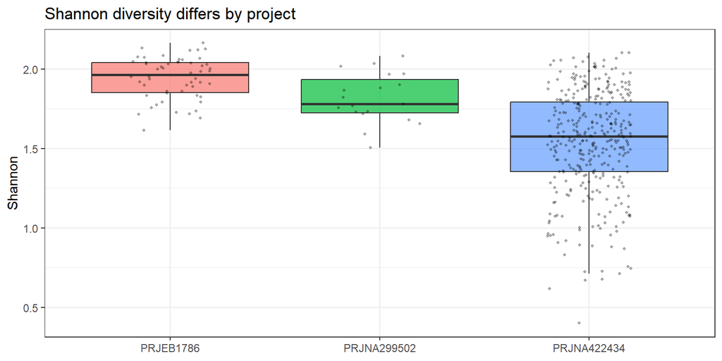

```r
ggplot(alpha_full, aes(x = Project.ID, y = Shannon, fill = Project.ID)) +
  geom_boxplot(alpha = 0.7, outlier.shape = NA) +
  geom_jitter(width = 0.2, alpha = 0.3, size = 0.8) +
  theme_bw() +
  theme(legend.position = "none") +
  labs(title = "Shannon diversity differs by project",
       x = NULL, y = "Shannon")
```

> *Reference: Kruskal-Wallis is the multi-group form of Wilcoxon — explicitly named in Alberdi’s “From counts to community” lecture §3 (Wilcoxon rank-sum). Boxplot + jitter style follows W20-02 §“Visualising alpha diversity” (`plot_richness()` produces equivalent point + boxplot).*

Shannon diversity differs dramatically across the three projects (Kruskal-Wallis χ² = 95.38, df = 2, p < 2.2 × 10⁻¹⁶). Median Shannon was highest in the European cohort (PRJEB1786, ~1.95), intermediate in the US cohort (PRJNA299502, ~1.78), and lowest in the Chinese cohort (PRJNA422434, ~1.55). Crucially, because all healthy controls are drawn from PRJNA422434 (the lowest-diversity population), any unadjusted T2D vs Healthy comparison on the full dataset would compare a cohort-mixed case group against a Chinese-only control group — guaranteeing a T2D > Healthy diversity pattern as a cohort artefact rather than a disease signal. This finding is the alpha-diversity analogue of the beta-diversity cohort effect quantified in §7, and provides additional structural justification for restricting analyses to PRJNA422434.

## 8.3 Pairwise comparisons across projects

```r
pairwise.wilcox.test(alpha_full$Shannon,
                     alpha_full$Project.ID,
                     p.adjust.method = "BH")
```

```
##
##  Pairwise comparisons using Wilcoxon rank sum test with continuity correction
##
## data:  alpha_full$Shannon and alpha_full$Project.ID
##
##             PRJEB1786 PRJNA299502
## PRJNA299502 0.00260   -
## PRJNA422434 < 2e-16   0.00012
##
## P value adjustment method: BH
```

> *Reference: W20-02 uses `pairwise.wilcox.test()` as the per-pair follow-up to an omnibus rank test; BH correction taught in Alberdi lecture §6 (Multiple testing & FDR) and W21 §8 (Control false discoveries with FDR).*

“All three pairwise project comparisons are significant after BH correction (Europe vs USA: p = 0.0026; Europe vs China: p < 2 × 10⁻¹⁶; USA vs China: p = 0.00012), with median Shannon decreasing Europe > USA > China. The cohort effect on alpha diversity is therefore pervasive across all project pairs, not localised to any single outlier study. This rules out partial-pooling strategies as alternatives to single-cohort restriction — any combination of two or more projects would re-introduce a significant geographic confound, and only restriction to PRJNA422434 yields a homogeneous within-cohort comparison.”

## 8.4 Median Shannon per project

A non-parametric description of where the three cohorts sit on the Shannon scale, in line with the boxplot of §8.2.

```r
alpha_full |>
  group_by(Project.ID) |>
  summarise(
    median_Shannon = median(Shannon, na.rm = TRUE),
    IQR_Shannon    = IQR(Shannon, na.rm = TRUE),
    n              = dplyr::n(),
    .groups = "drop"
  )
```

```
## # A tibble: 3 × 4
##   Project.ID  median_Shannon IQR_Shannon     n
##   <fct>                <dbl>       <dbl> <int>
## 1 PRJEB1786             1.96       0.190    54
## 2 PRJNA299502           1.78       0.210    19
## 3 PRJNA422434           1.58       0.440   359
```

> *Reference: medians + IQR per group are the descriptive summary used alongside Wilcoxon in W20-02 §“Statistical testing of alpha diversity”.*

# 9. Disease effect, adjusted for cohort

What is the disease effect on Shannon once we control for project?

```r
mod_unadjusted <- lm(Shannon ~ Disease.MESH.ID,
                     data = alpha_full)
mod_adjusted   <- lm(Shannon ~ Disease.MESH.ID + Project.ID,
                     data = alpha_full)

summary(mod_unadjusted)$coefficients
```

```
##                          Estimate Std. Error   t value      Pr(>|t|)
## (Intercept)             1.6796033 0.01958953 85.739831 1.646337e-272
## Disease.MESH.IDD006262 -0.1903864 0.03104572 -6.132453  1.962203e-09
```

```r
summary(mod_adjusted)$coefficients
```

```
##                          Estimate Std. Error   t value      Pr(>|t|)
## (Intercept)             1.9428909 0.04017874 48.356188 1.527907e-175
## Disease.MESH.IDD006262 -0.1006753 0.03119288 -3.227509  1.344741e-03
## Project.IDPRJNA299502  -0.1286324 0.07875552 -1.633313  1.031386e-01
## Project.IDPRJNA422434  -0.3529988 0.04561252 -7.739076  7.276893e-14
```

> *Reference: W21 §7 (Adjust the linear model for health status) — uses `glm(response ~ predictor + covariate)` with the same nested-model comparison logic. Alberdi lecture §5 (Linear models & covariates) is the underlying theory.* “A linear model on the unfiltered Shannon data showed that Healthy samples had 0.190 Shannon units lower diversity than T2D samples (β = −0.190, p = 1.96 × 10⁻⁹). After adjusting for Project.ID, this disease coefficient shrank by 47% to β = −0.101 (p = 0.0013), while the China-vs-Europe project coefficient (β = −0.353, p = 7.3 × 10⁻¹⁴) was 3.5 times larger than the adjusted disease coefficient. The unadjusted disease estimate therefore packages together genuine within-population disease variation and the cohort-mixing artefact of comparing a Chinese-only Healthy group against a partly non-Chinese T2D group. The adjusted estimate is the unconfounded disease effect; restricting analyses to PRJNA422434 yields the same comparison without requiring covariate adjustment in every downstream test.”

The Disease coefficient in the adjusted model is the disease effect on Shannon after partialling out cohort. Comparison with the unadjusted coefficient shows how much of the apparent disease effect was actually cohort-driven.

# 10. Biological interpretation of the cohort effect

The numbers from §7-§9 show that `Project.ID` (and equivalently `Country`) is the largest single driver of community variation in this dataset. Several lines of published evidence explain why this is expected biology, not an analytical artefact:

- **Diet** is the dominant short-to-medium-term driver of gut community composition. Different countries differ systematically in fibre intake, fermented-food consumption, animal vs plant protein, food additives. Each has measurable microbiome consequences.
- **Lifestyle and host genetics** — urbanisation, antibiotic-use patterns, mode of birth, breastfeeding duration, host genetic background — vary across populations and all affect microbiome composition.
- **Cross-country surveys** (Yatsunenko et al. 2012; the Human Microbiome Project; American Gut Project) consistently report that population-of-origin explains a substantial fraction of microbiome variance — often comparable to or greater than the variance explained by disease.

Together, this means that the observed project effect is real biology — a real difference between Chinese, Swedish, and other contributing populations. It is also irrelevant biology *for the disease question we want to answer*. We do not want to know how the Chinese microbiome differs from the Scandinavian microbiome; we want to know how the T2D gut microbiome differs from the healthy gut microbiome.

# 11. What filtering achieves biologically

Restricting to PRJNA422434 sacrifices ~17% of the sample size (73 of 432 samples) to gain four substantial benefits, each supported by the analyses above:

**1. The disease signal is no longer confounded with population-of-origin.** Within a single Chinese cohort, participants share roughly the same dietary patterns, urbanisation profile, antibiotic-use environment, and host-genetic background. A taxon found T2D-associated in this comparison is associated with T2D *within the Chinese population* — a defensible biological claim. The same taxon in the full-data comparison could plausibly reflect a Chinese-vs-Scandinavian signal, given the magnitude of the project effect in §7.

**2. Reduced technical noise.** Samples within one project share DNA extraction protocol, sequencing platform, and bioinformatic pipeline. The dispersion test in §7.8 shows that across-project dispersion is itself measurable; filtering removes that contribution.

**3. Taxa with meaningful disease-related variance, rather than population-marker variance.** Many low-abundance taxa appear in only one geographic population. In the full dataset, those taxa generate “signals” that are really population markers. Within one population, the taxa with meaningful variance are those that genuinely fluctuate with disease state.

**4. Cleaner downstream interpretation.** When we move to differential abundance and map T2D-associated taxa to known biology (SCFA producers, mucin degraders, bile-acid modifiers), the interpretation is unambiguous: these are taxa whose abundance differs in Chinese T2D patients compared to Chinese healthy controls. In the full dataset, every interpretive sentence would need to qualify whether the finding is disease- or population-specific.

# 12. What we lose, and why it is acceptable

**Generalisability.** Findings are formally specific to the Chinese gut microbiome. They cannot be claimed to generalise to Scandinavian, North American, or other populations without further validation.

This is a genuine limitation, acceptable for two reasons:

- Even with the full dataset, the controls are exclusively Chinese — so the “Healthy reference” was always going to be Chinese-specific. Filtering does not narrow the implicit population framing; it makes it explicit.
- The T2D microbiome literature has repeatedly shown that “universal” microbiome signatures fail to replicate across cohorts (Forslund et al. 2015 demonstrated this for T2D in particular). Honest population-specificity is methodologically preferable to a misleading claim of generality.

**Sample size.** N drops from 432 to 359. A 17% reduction. PERMANOVA, Wilcoxon, and differential-abundance methods all retain ample power at n = 359.

# 13. Methodological framing

Restricting to PRJNA422434 is not a result-driven choice. The decision is dictated by:

1. The structure of the dataset — two of three projects are case-only (§5).
2. The numerical demonstration that cohort dominates the community signal more than disease does (§7.4-§7.7).
3. The biological knowledge that country-of-origin is a major microbiome driver, confounded with disease in the original design (§10).

All three reasons exist before any downstream analysis is run. The choice is therefore conservative (sacrifices nominal sample size for cleaner interpretation), structural (reflects an unfixable feature of the design), and biological (isolates the comparison we want to make).

# 14. Summary

- 432 samples; three projects; two of three are case-only (§5).
- The single case-control project (PRJNA422434, n = 359) is the Chinese cohort (§6).
- PERMANOVA on Project alone yields a substantial R² (§7.4); Project R² far exceeds Disease R² in the adjusted PERMANOVA (§7.7); Shannon diversity differs significantly between projects (§8.2-§8.4).
- All of these results are quantitative confirmation that cohort dominates the community signal in this dataset.
- Country is one of the largest known drivers of gut microbiome composition (§10), so the cohort effect documented here is real biology that is irrelevant to the disease question.
- Restricting to PRJNA422434 isolates a within-population disease comparison, both structurally honest and biologically interpretable (§11).
- The costs — loss of 17% of samples and loss of cross-population generalisability — are acknowledged (§12).
- **Conclusion**: filtering is the better choice for the biology we want to characterise, and the rationale rests on demonstrated tests, not assertion.